# annotate_bedpe_csv_rna

# networkx plotting

```python
tf_tf_count_df = pd.read_csv('atac_footprinting/hoco_tf_tf_overlap_counts.csv', index_col=0)
tf_tf_count_df_long = pd.read_csv('atac_footprinting/hoco_tf_tf_overlap_counts_long.csv', index_col=0)
tf_tf_avg_df = pd.read_csv('atac_footprinting/hoco_tf_tf_overlap_avg.csv', index_col=0)
tf_tf_avg_df_long = pd.read_csv('atac_footprinting/hoco_tf_tf_overlap_avg_long.csv', index_col=0)
```

```python
# tf_tf_count_df_long
```

```python
# tf_tf_avg_df_long[tf_tf_avg_df_long.avg>.5]
```

```python
tf_tf_avg_df_long_filt = tf_tf_avg_df_long[tf_tf_avg_df_long.TF1 != tf_tf_avg_df_long.TF2]
tf_tf_avg_df_long_filt = tf_tf_avg_df_long_filt[tf_tf_avg_df_long_filt.avg>.99]
```

```python
tf_tf_avg_df_long_filt
```

|  | TF1 | TF2 | avg |
| --- | --- | --- | --- |
| 3 | NR3C1 | AR | 1.0 |
| 5 | ZFP82 | AR | 1.0 |
| 12 | ATF2 | ATF1 | 1.0 |
| 14 | ATF4 | ATF1 | 1.0 |
| 15 | CREB1 | ATF1 | 1.0 |
| ... | ... | ... | ... |
| 1803 | SALL4 | ZNF770 | 1.0 |
| 1805 | SP2 | ZNF770 | 1.0 |
| 1810 | ZNF263 | ZNF770 | 1.0 |
| 1819 | INSM1 | ZSCAN22 | 1.0 |
| 1823 | ZNF263 | ZSCAN22 | 1.0 |

596 rows × 3 columns

```python
G = nx.convert_matrix.from_pandas_edgelist(tf_tf_avg_df_long_filt, 'TF1', 'TF2', 'avg')
```

```python
tf_to_family = pd.Series(hoco_annon['TF family'].values,index=hoco_annon['Transcription factor'].values).to_dict()
tf_to_subfamily = pd.Series(hoco_annon['TF subfamily'].values,index=hoco_annon['Transcription factor'].values).to_dict()
```

[figure not shown]

```
Counter({'More than 3 adjacent zinc finger factors{2.3.3}': 27, 'Three-zinc finger Krüppel-related factors{2.3.1}': 13, 'Ets-related factors{3.5.2}': 12, 'Factors with multiple dispersed zinc fingers{2.3.4}': 10, 'Thyroid hormone receptor-related factors (NR1){2.1.2}': 9, 'Forkhead box (FOX) factors…
Counter({'unclassified{2.3.3.0}': 9, 'Krüppel-like factors{2.3.1.2}': 8, 'Ets-like factors{3.5.2.1}': 6, 'Elk-like factors{3.5.2.2}': 5, 'E2F{3.3.2.1}': 5, 'unclassified{2.3.4.0}': 4, 'Fos factors{1.1.2.1}': 4, 'CREB-like factors{1.1.7.1}': 3, 'GR-like receptors (NR3C){2.1.1.1}': 3, 'Small Maf facto…
```

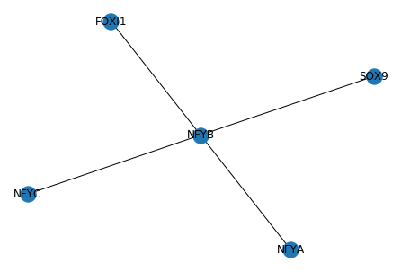

```
Counter({'Heteromeric CCAAT-binding factors{4.2.1}': 3, 'SOX-related factors{4.1.1}': 1, 'Forkhead box (FOX) factors{3.3.1}': 1})
Counter({'NF-YA (CP1A, CBF-B){4.2.1.0.1}': 1, 'NF-YB (CP1B, CBF-A){4.2.1.0.2}': 1, 'NF-YC{4.2.1.0.3}': 1, 'Group E{4.1.1.5}': 1, 'FOXI{3.3.1.9}': 1})
```

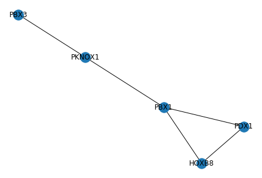

```
Counter({'TALE-type homeo domain factors{3.1.4}': 3, 'HOX-related factors{3.1.1}': 2})
Counter({'PBX{3.1.4.4}': 2, 'PDX{3.1.1.15}': 1, 'HOX8{3.1.1.7}': 1, 'PKNOX{3.1.4.5}': 1})
```

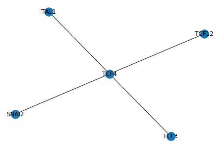

```
Counter({'E2A-related factors{1.2.1}': 3, 'More than 3 adjacent zinc finger factors{2.3.3}': 1, 'Tal-related factors{1.2.3}': 1})
Counter({'HTF-4 (TCF-12, HEB){1.2.1.0.3}': 1, 'E2A (TCF-3, ITF-1){1.2.1.0.1}': 1, 'Snail-like factors{2.3.3.2}': 1, 'SEF2 (E2-2, TCF-4, ITF-2){1.2.1.0.2}': 1, 'Tal / HEN-like factors{1.2.3.1}': 1})
```

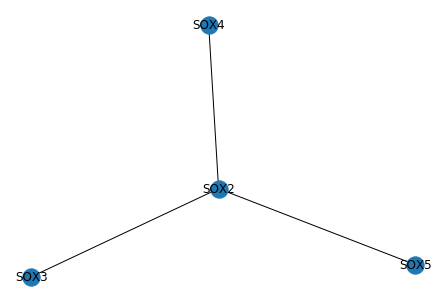

```
Counter({'SOX-related factors{4.1.1}': 4})
Counter({'Group B{4.1.1.2}': 2, 'Group D{4.1.1.4}': 1, 'Group C{4.1.1.3}': 1})
```

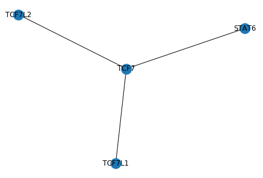

```
Counter({'TCF-7-related factors{4.1.3}': 3, 'STAT factors{6.2.1}': 1})
Counter({'TCF-7L1 (TCF-3) [1]{4.1.3.0.2}': 1, 'STAT6{6.2.1.0.7}': 1, 'TCF-7L2 (TCF-4) [1]{4.1.3.0.3}': 1, 'TCF-7 (TCF-1) [1]{4.1.3.0.1}': 1})
```

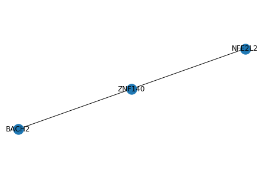

```
Counter({'Jun-related factors{1.1.1}': 2, 'More than 3 adjacent zinc finger factors{2.3.3}': 1})
Counter({'NF-E2-like factors{1.1.1.2}': 2, 'ZNF302-like factors{2.3.3.44}': 1})
```

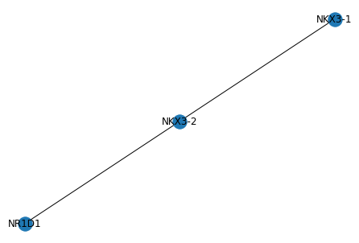

```
Counter({'NK-related factors{3.1.2}': 2, 'Thyroid hormone receptor-related factors (NR1){2.1.2}': 1})
Counter({'NK-3{3.1.2.16}': 2, 'Rev-ErbA (NR1D){2.1.2.3}': 1})
```

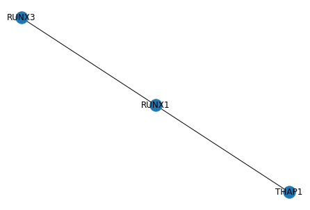

```
Counter({'Runt-related factors{6.4.1}': 2, 'THAP-related factors{2.9.1}': 1})
Counter({'Runx3 (PEBP2alphaC, CBF-alpha3, AML-2){6.4.1.0.3}': 1, 'Runx1 (PEBP2alphaB, CBF-alpha2, AML-1){6.4.1.0.2}': 1, 'THAP1{2.9.1.0.1}': 1})
```

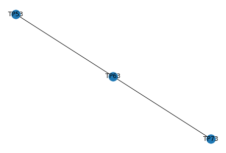

```
Counter({'p53-related factors{6.3.1}': 3})
Counter({'p63{6.3.1.0.2}': 1, 'p53{6.3.1.0.1}': 1, 'p73{6.3.1.0.3}': 1})
```

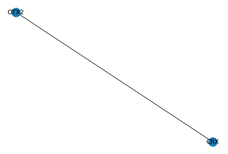

```
Counter({'Paired-related HD factors{3.1.3}': 2})
Counter({'OTX{3.1.3.17}': 2})
```

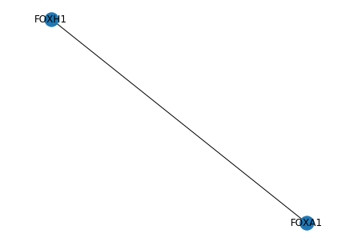

```
Counter({'Forkhead box (FOX) factors{3.3.1}': 2})
Counter({'FOXH{3.3.1.8}': 1, 'FOXA{3.3.1.1}': 1})
```

[6 more figures not shown]

```
Counter({'AP-2{1.3.1}': 2})
Counter({'AP-2gamma{1.3.1.0.3}': 1, 'AP-2alpha{1.3.1.0.1}': 1})
num_in_connected_comp 220
```

```python
num_in_connected_comp = 0
for comp_nodes in sorted(nx.connected_components(G), key=len, reverse=True):
    num_in_connected_comp+=len(comp_nodes)
    subgraph = G.subgraph(comp_nodes)
    nx.draw(subgraph,with_labels=True,pos=nx.spring_layout(subgraph))
    plt.show()
    print(Counter([tf_to_family.get(tf) for tf in comp_nodes]))
    print(Counter([tf_to_subfamily.get(tf) for tf in comp_nodes]))
print('num_in_connected_comp',num_in_connected_comp)
```

[figure not shown]

```python
# for subgraph in G:

nx.draw(G,with_labels=True,pos=nx.spring_layout(G))
plt.show()
```

```python
# tf_tf_dict = {}
# for tf in tfs_list:
#     tf_tf_dict[tf] = defaultdict(list)

# MAX_TF_LEN = 24
# for foot_chr in tf_df.foot_chr.unique():
#     tf_df_filt = tf_df[tf_df.foot_chr == foot_chr]
#     tf_df_filt_list = list(zip(tf_df_filt['foot_start'], tf_df_filt['foot_end'], tf_df_filt['transcription_factor']))
#     print(foot_chr, tf_df_filt.shape)
# #     for idx, anchor in tf_df_filt.iterrows():
#     for idx, anchor in enumerate(tf_df_filt_list):
# #         # DEBUG
# #         if (idx %10000)==0:
# #             print(idx)

#         s_start, s_end, s_tf = anchor[0], anchor[1], anchor[2]
#         idx_check = idx+1
#         while idx_check>0 and idx_check<len(tf_df_filt_list):
#             t_start, t_end, t_tf = tf_df_filt_list[0][0], tf_df_filt_list[0][1], tf_df_filt_list[0][2]
#             perc = percent_overlap((s_start, s_end),(t_start, t_end))
#             if perc > 0:
#                 tf_tf_dict[s_tf][t_tf].append(perc)
#                 tf_tf_dict[t_tf][s_tf].append(perc)
#                 idx_check+=1 #keep searching
#             else:
#                 idx_check=-1 # exit condition

# #         s_start, s_end, s_tf = anchor['foot_start'], anchor['foot_end'], anchor['transcription_factor']
# #         search_region_df = tf_df_filt[(tf_df_filt.foot_start > (s_start - MAX_TF_LEN - 1 )) &
# #                                    (tf_df_filt.foot_end < (s_end + MAX_TF_LEN + 1 ))]
# #         for jdx, search in search_region_df.iterrows():
# #             t_start, t_end, t_tf = search['foot_start'], search['foot_end'], search['transcription_factor']
# #             perc = percent_overlap((s_start, s_end),(t_start, t_end))
# #             if perc > 0:
# #                 tf_tf_dict[s_tf][t_tf].append(perc)
# #                 tf_tf_dict[t_tf][s_tf].append(perc)


# #     print(max(tf_df_filt.foot_end - tf_df_filt.foot_start))
```

# 4. annotating missing TSS

problem found in `crms_tf_housekeeping`

interesting aside: seems to have a binning issue because the TSS of TP63 doesn't show up in any of the anchors for the tissues in which TP63 is expressed. it seems like the binning software called the loop anchors for this gene in the adjacent bin (downstream). it could be because the gene body is more open and more stuff can touch it thus the gene body has more "hits" for loops and the software calls the downstream 5kb bin rather than the region with the TSS

a work around is for each gene present in the `gene` column in anchor_df that doesn't have an annotated `TSS` within the anchor file, find the closest 5kb anchor and annotate as such

This is done in `annotate_bedpe_csv_rna.ipynb` 4th section

- note: then update anchors and save to same location as `new_bedpe_dir` 01/14/2020

```python
tss_file = 'annon/TSS_annon_ALL.csv'
tss_df = pd.read_csv(tss_file, index_col=0,header=0)
tss_df['chr'] = 'chr'+tss_df.seqnames.map(str)
tss_df = tss_df[['chr', 'start', 'gene']]
tss_df = tss_df.sort_values(['chr','start']).reset_index(drop=True)
print(tss_df.shape)
tss_df[:5]
```

```
(20260, 3)
```

|  | chr | start | gene |
| --- | --- | --- | --- |
| 0 | chr1 | 69091 | OR4F5 |
| 1 | chr1 | 139379 | AL627309.1 |
| 2 | chr1 | 367640 | OR4F29 |
| 3 | chr1 | 622053 | OR4F16 |
| 4 | chr1 | 739137 | AL669831.1 |

```python
for anchors_file in glob.glob(os.path.join(new_bedpe_dir, "*merged.anchors.csv")):
    start = time.time()
    tissue = os.path.basename(anchors_file).split('-')[0]
    anchors_df = pd.read_csv(anchors_file, index_col=0, header=0)
#     anchors_df['anchors'].str.split('_',expand=True).to_csv(new_file, sep='\t',header=False, index=False)

    gene_set = set()
    for gene_str in anchors_df.gene.unique():
        if type(gene_str)==str:
            gene_set=gene_set.union(set(gene_str.split('::')))

    TSS_set = set()
    for TSS_str in anchors_df.TSS.unique():
        if type(TSS_str)==str:
            TSS_set=TSS_set.union(set(TSS_str.split('::')))

    TSS_not_found = gene_set - TSS_set
    TSS_not_found = TSS_not_found.intersection(set(tss_df.gene))
    print(tissue, len(TSS_set), len(gene_set), len(TSS_not_found),time.time() - start)
    for tss in list(TSS_not_found):
        row = tss_df[tss_df.gene==tss].values[0]
        chrom_tss, loc_tss = row[0],row[1]
        anchors_df_filt = anchors_df[anchors_df.chr==chrom_tss]
        anchors_df_filt['how_close_start'] = abs(anchors_df_filt.loc[:,'start'] -  loc_tss)
        anchors_df_filt['how_close_end'] = abs(loc_tss - anchors_df_filt.loc[:,'end'])
        anchors_df_filt['how_close'] = anchors_df_filt.loc[:,['how_close_start','how_close_end']].min(axis=1)
        orig_row_idx = anchors_df_filt.sort_values('how_close').reset_index().loc[0,'index']
        orig_row = anchors_df.loc[orig_row_idx,:]
        if orig_row['num_TSS']==0:
            anchors_df.at[orig_row_idx,'num_TSS'] = 1
            anchors_df.at[orig_row_idx,'TSS'] = tss
        else:
            anchors_df.at[orig_row_idx,'num_TSS'] += 1
            anchors_df.at[orig_row_idx,'TSS'] += '::' + tss


    print(tissue, 'done annotating TSSs...', time.time() - start)
    # update rna
    rna_tissue = tissue_diffloop_to_rna[tissue]
    anchors_df_rna = update_anchors(anchors_df, rna_tissue, verbose=False)
    anchors_df_rna.to_csv(anchors_file)
    print(tissue, 'done updating and saving...', time.time() - start)
```

```
Ova 11610 13555 2808 3.512909173965454
```

```
Ova done annotating TSSs... 40.7948100566864
Ova done updating and saving... 55.075305223464966
MC 6791 10091 4153 1.4270477294921875
MC done annotating TSSs... 40.798789739608765
MC done updating and saving... 49.7536780834198
Panc 9008 11082 3217 1.8063488006591797
Panc done annotating TSSs... 29.33502197265625
Panc done updating and saving... 39.97337508201599
Thy 11704 13563 2758 2.902698040008545
Thy done annotating TSSs... 31.404508113861084
Thy done updating and saving... 46.650827169418335
Eso 11426 13256 2767 2.712308168411255
Eso done annotating TSSs... 869.1408700942993
Eso done updating and saving... 914.5032868385315
Blad 9767 12361 3647 12.379462003707886
Blad done annotating TSSs... 200.2150068283081
Blad done updating and saving... 218.27590107917786
GM12878 9822 12440 3428 2.9206960201263428
GM12878 done annotating TSSs... 50.62059712409973
GM12878 done updating and saving... 65.18948006629944
GDSD6 8493 11837 4134 1.9776339530944824
GDSD6 done annotating TSSs... 48.85702109336853
GDSD6 done updating and saving... 63.41661715507507
Renal 10992 13610 3433 2.739081859588623
```

[output not shown]

[output cut: 5345 more lines]

[output not shown]

```
Renal done annotating TSSs... 48.94206690788269
Renal done updating and saving... 68.13705492019653
Uter 12780 15349 3273 3.6175479888916016
```

[output not shown]

[output cut: 11480 more lines]

[output not shown]